# IABE Data Science Certificate - Module 1

Olivier Soupart  
Derya Turkoz

# Import de la base de données

```python
import pandas as pd
my_data = pd.read_csv("https://gitfront.io/r/katrienantonio/a29071bdc7b2f20f24268be573ef54b68c65168c/IABE-DS-module-1/raw/assignment/assignment_data.csv", delimiter = ",")
my_data.head
```

[output not shown]

[output cut: 25 more lines]

**Est-ce que la DB a bien été importée?**

```python
my_data.head()
```

|  | AGEPH | CODPOSS | duree | lnexpo | nbrtotc | nbrtotan | chargtot | agecar | sexp | fuelc | split | usec | fleetc | sportc | coverp | powerc |
| --- | --- | --- | --- | --- | --- | --- | --- | --- | --- | --- | --- | --- | --- | --- | --- | --- |
| 0 | 64 | 1000 | 1.000000 | 0.000000 | 0 | 0.000000 | 0.000000 | 2-5 | Female | Petrol | Once | Private | No | No | MTPL+ | 66-110 |
| 1 | 28 | 1000 | 0.046575 | -3.066684 | 1 | 21.470588 | 155.974606 | 6-10 | Female | Petrol | Twice | Private | No | No | MTPL | 66-110 |
| 2 | 58 | 1000 | 0.402740 | -0.909465 | 0 | 0.000000 | 0.000000 | >10 | Female | Petrol | Thrice | Private | No | No | MTPL | <66 |
| 3 | 37 | 1030 | 0.169863 | -1.772763 | 0 | 0.000000 | 0.000000 | 2-5 | Female | Petrol | Once | Professional | No | No | MTPL+++ | 66-110 |
| 4 | 29 | 1030 | 1.000000 | 0.000000 | 0 | 0.000000 | 0.000000 | 6-10 | Female | Petrol | Once | Private | No | No | MTPL+ | <66 |

=> ok

# Import des différents packages nécessaires

```python
import math
import warnings; warnings.filterwarnings("ignore") #delete warnings
import pandas as pd
import numpy as np
import seaborn as sb
import matplotlib.pyplot as plt

import statsmodels.api as sm
import scipy.stats as ss

import random

import statsmodels.formula.api as smf

from sklearn.model_selection import train_test_split
from sklearn.model_selection import cross_val_score
from sklearn.model_selection import RepeatedStratifiedKFold
from sklearn.model_selection import KFold

from sklearn.compose import ColumnTransformer
from sklearn.preprocessing import StandardScaler, MinMaxScaler
from sklearn.pipeline import make_pipeline
from sklearn.linear_model import LinearRegression
from sklearn.metrics import mean_squared_error

# run !pip install feature_engine in colab as it is not in the evironment by default
from feature_engine.encoding import OrdinalEncoder, OneHotEncoder
```

# Analyse explorative de la base de données

Les colonnes reprises dans la Db sont les suivantes:

```python
my_data.columns
```

```
Index(['AGEPH', 'CODPOSS', 'duree', 'lnexpo', 'nbrtotc', 'nbrtotan',
       'chargtot', 'agecar', 'sexp', 'fuelc', 'split', 'usec', 'fleetc',
       'sportc', 'coverp', 'powerc'],
      dtype='object')
```

La DB contient 163657 lignes et 16 colonnes:

```python
my_data.shape
```

```
(163657, 16)
```

**Plus d'informations sur le type des variables:**

```python
print("My Data")
print(my_data.info())
```

```
My Data
<class 'pandas.core.frame.DataFrame'>
RangeIndex: 163657 entries, 0 to 163656
Data columns (total 16 columns):
 #   Column    Non-Null Count   Dtype
---  ------    --------------   -----
 0   AGEPH     163657 non-null  int64
 1   CODPOSS   163657 non-null  int64
 2   duree     163657 non-null  float64
 3   lnexpo    163657 non-null  float64
 4   nbrtotc   163657 non-null  int64
 5   nbrtotan  163657 non-null  float64
 6   chargtot  163657 non-null  float64
 7   agecar    163657 non-null  object
 8   sexp      163657 non-null  object
 9   fuelc     163657 non-null  object
 10  split     163657 non-null  object
 11  usec      163657 non-null  object
 12  fleetc    163657 non-null  object
 13  sportc    163657 non-null  object
 14  coverp    163657 non-null  object
 15  powerc    163657 non-null  object
dtypes: float64(4), int64(3), object(9)
memory usage: 20.0+ MB
None
```

On voit qu'il n'y a pas de variable null

**Y'a-t-il des données manquantes dans la DB?**

```python
print(my_data.isna().sum())
```

```
AGEPH       0
CODPOSS     0
duree       0
lnexpo      0
nbrtotc     0
nbrtotan    0
chargtot    0
agecar      0
sexp        0
fuelc       0
split       0
usec        0
fleetc      0
sportc      0
coverp      0
powerc      0
dtype: int64
```

=> aucune donnée manquante

**Conversion en variables catégoriques:**

```python
for c in [
"agecar",
"sexp",
"fuelc",
"split",
"usec",
"fleetc",
"sportc",
"coverp",
"powerc"]:
    my_data[c]=pd.Categorical(my_data[c])
```

```python
my_data.dtypes.value_counts()
```

```
float64     4
int64       3
category    2
category    1
category    1
category    1
category    1
category    1
category    1
category    1
dtype: int64
```

### *Fréquence sinistres*

La **fréquence sinistre** moyenne observée est de :

```python
my_data.nbrtotc.sum()/my_data.duree.sum()
```

```
0.1393355156734497
```

Exposition par nombre de sinistres:

```python
my_data["nbrtotc"].value_counts()
```

```
0    145312
1     16602
2      1562
3       162
4        17
5         2
Name: nbrtotc, dtype: int64
```

=> 145312 contrats (année - exposition) n'ont pas eu de sinistres  
=> 16602 contrats ont eu un sinistre

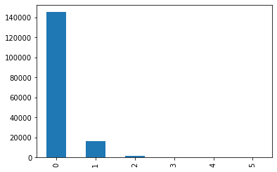

```python
#For mtpl we first construct a simple bar plot to picture the empirical distribution of the number of claims reported.
my_data["nbrtotc"].value_counts().plot(kind = "bar")
```

```python
emp_freq = my_data.groupby("nbrtotc").agg(tot_obs = ('nbrtotc', 'count'), tot_expo = ('duree', 'sum'))
emp_freq
```

| nbrtotc | tot_obs | tot_expo |
| --- | --- | --- |
| 0 | 145312 | 128595.947945 |
| 1 | 16602 | 15410.320548 |
| 2 | 1562 | 1447.301370 |
| 3 | 162 | 150.454795 |
| 4 | 17 | 14.328767 |
| 5 | 2 | 1.375342 |

```python
emp_freq.reset_index(inplace = True)
emp_freq
```

|  | nbrtotc | tot_obs | tot_expo |
| --- | --- | --- | --- |
| 0 | 0 | 145312 | 128595.947945 |
| 1 | 1 | 16602 | 15410.320548 |
| 2 | 2 | 1562 | 1447.301370 |
| 3 | 3 | 162 | 150.454795 |
| 4 | 4 | 17 | 14.328767 |
| 5 | 5 | 2 | 1.375342 |

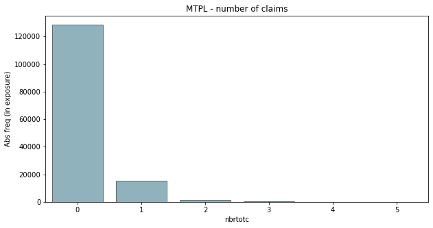

```python
KULbg =  "#116E8A"
plt.figure(figsize = (10, 5))
sb.barplot(data = emp_freq, x = "nbrtotc", y = "tot_expo", alpha = 0.5, color=KULbg,
               edgecolor = 'black', linewidth = 1)
plt.ylabel("Abs freq (in exposure)")
plt.xlabel("nbrtotc")
plt.title('MTPL - number of claims')
plt.show()
```

### *Coût moyen*

Le coût moyen observé est de :

```python
my_data.chargtot.sum()/my_data.nbrtotc.sum()
```

```
1622.0543005764382
```

```python
my_data["avg"]=my_data.chargtot/my_data.nbrtotc
```

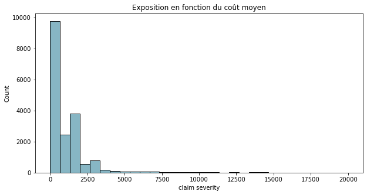

```python
KULbg =  "#116E8A"
plt.figure(figsize=(10,5));
sb.histplot(data=my_data, x= "avg",color=KULbg, alpha=0.5, bins=30, binrange=[0,20000])
plt.xlabel("claim severity")
plt.title("Exposition en fonction du coût moyen")
plt.show()
```

### Age du preneur

```python
def description_analysis2(variable,data):

    Nbr = data['nbrtotc'].groupby([data[variable]]).sum().reset_index()
    exp = data[['duree']].groupby([data[variable]]).sum().reset_index()
    charge = data[['chargtot']].groupby([data[variable]]).sum().reset_index()
    obs = pd.merge(Nbr,exp)
    obs = pd.merge(obs,charge)
    obs['Freq']=obs['nbrtotc']/obs['duree']
    obs['AVG']=obs['chargtot']/obs['nbrtotc']

    table=obs

    #frequency plot
    plt.rcParams['figure.figsize'] = [20, 6]
    table_to_plot=table.loc[:,[variable,'duree','Freq']]
    table_to_plot[variable]=table_to_plot[variable].astype("category")
    table_to_plot.plot(kind='bar', secondary_y='duree', rot=30)
    plt.xticks(range(table_to_plot.shape[0]),list(table_to_plot.iloc[:,0]), rotation=30)
    plt.title('Frequency')
    plot=plt.show()

    #severity plot
    plt.rcParams['figure.figsize'] = [20, 6]
    table_to_plot=table.loc[:,[variable,'duree','AVG']]
    table_to_plot[variable]=table_to_plot[variable].astype("category")
    table_to_plot.plot(kind='bar', secondary_y='duree', rot=30)
    plt.xticks(range(table_to_plot.shape[0]),list(table_to_plot.iloc[:,0]), rotation=30)
    plt.title('Severity')
    plot=plt.show()

    return(obs)
```

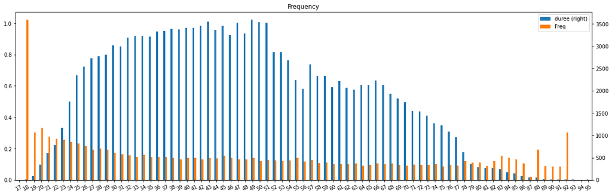

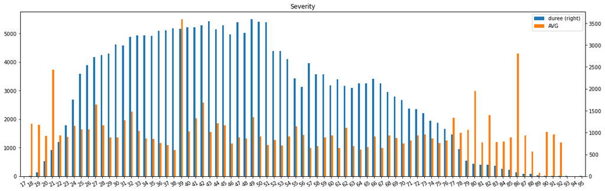

|  | AGEPH | nbrtotc | duree | chargtot | Freq | AVG |
| --- | --- | --- | --- | --- | --- | --- |
| 0 | 17 | 0 | 1.693151 | 0.000000 | 0.000000 | NaN |
| 1 | 18 | 5 | 4.890411 | 9222.457170 | 1.022409 | 1844.491434 |
| 2 | 19 | 28 | 93.021918 | 50489.862394 | 0.301004 | 1803.209371 |
| 3 | 20 | 113 | 342.284932 | 158953.467906 | 0.330134 | 1406.667858 |
| 4 | 21 | 166 | 600.219178 | 619270.027935 | 0.276566 | 3730.542337 |
| ... | ... | ... | ... | ... | ... | ... |
| 74 | 91 | 1 | 11.827397 | 1471.793435 | 0.084549 | 1471.793435 |
| 75 | 92 | 4 | 13.232877 | 4743.640911 | 0.302277 | 1185.910228 |
| 76 | 93 | 0 | 7.167123 | 0.000000 | 0.000000 | NaN |
| 77 | 94 | 0 | 3.000000 | 0.000000 | 0.000000 | NaN |
| 78 | 95 | 0 | 3.734247 | 0.000000 | 0.000000 | NaN |

79 rows × 6 columns

```python
description_analysis2("AGEPH",my_data)
```

### Age du preneur : Création de nouvelles classes

```python
my_data["AGEPH2"] = np.where(my_data['AGEPH'] < 21, "A.18-20",
                                       np.where(my_data['AGEPH'] <26 ,"B.21-25", \
                              np.where(my_data['AGEPH'] < 31, "C.26-30",
                                       np.where(my_data['AGEPH'] < 41, "D.31-40", \
                              np.where(my_data['AGEPH'] < 51, "E.41-50",
                                       np.where(my_data['AGEPH'] < 61, "F.51-60", \
                              np.where(my_data['AGEPH'] < 71, "G.61-70","I.>70")))))))
```

```python
my_data.AGEPH2.value_counts()
```

```
E.41-50    38722
D.31-40    37699
F.51-60    28349
G.61-70    22115
C.26-30    16074
I.>70      12421
B.21-25     7749
A.18-20      528
Name: AGEPH2, dtype: int64
```

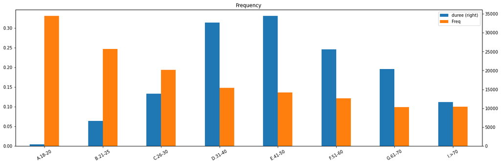

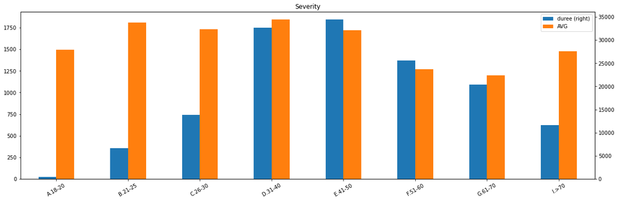

|  | AGEPH2 | nbrtotc | duree | chargtot | Freq | AVG |
| --- | --- | --- | --- | --- | --- | --- |
| 0 | A.18-20 | 146 | 441.890411 | 2.186658e+05 | 0.330399 | 1497.710873 |
| 1 | B.21-25 | 1641 | 6651.643836 | 2.972822e+06 | 0.246706 | 1811.591513 |
| 2 | C.26-30 | 2691 | 13858.789041 | 4.655452e+06 | 0.194173 | 1730.008054 |
| 3 | D.31-40 | 4833 | 32664.112329 | 8.904933e+06 | 0.147961 | 1842.526988 |
| 4 | E.41-50 | 4699 | 34394.246575 | 8.087287e+06 | 0.136622 | 1721.065510 |
| 5 | F.51-60 | 3088 | 25556.167123 | 3.922162e+06 | 0.120832 | 1270.130215 |
| 6 | G.61-70 | 2025 | 20403.712329 | 2.428295e+06 | 0.099247 | 1199.158056 |
| 7 | I.>70 | 1167 | 11649.167123 | 1.721866e+06 | 0.100179 | 1475.463322 |

```python
description_analysis2("AGEPH2",my_data)
```

**Constatations:**

- la fréquence sinistres diminue avec l'âge
- au niveau de la sévérité, on n'observe pas de tendance claire

```python
my_data["AGEPH3"] = np.where(my_data['AGEPH'] < 21, "A.18-20",
                         np.where(my_data['AGEPH'] <31 ,"B.21-30", \
                             np.where(my_data['AGEPH'] < 41, "C.31-50", \
                              np.where(my_data['AGEPH'] < 51, "C.31-50","D.>50",))))
```

```python
my_data.AGEPH3.value_counts()
```

```
C.31-50    76421
D.>50      62885
B.21-30    23823
A.18-20      528
Name: AGEPH3, dtype: int64
```

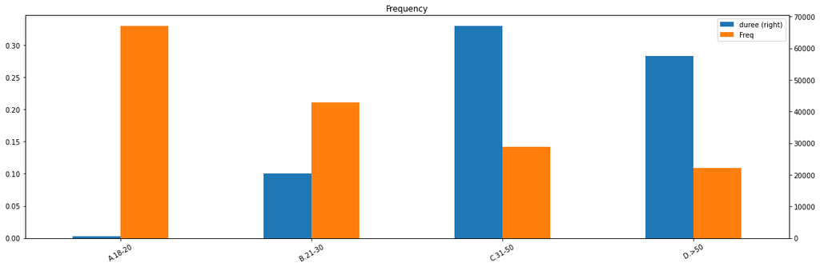

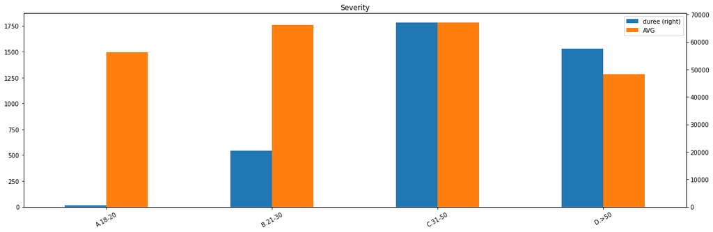

|  | AGEPH3 | nbrtotc | duree | chargtot | Freq | AVG |
| --- | --- | --- | --- | --- | --- | --- |
| 0 | A.18-20 | 146 | 441.890411 | 2.186658e+05 | 0.330399 | 1497.710873 |
| 1 | B.21-30 | 4332 | 20510.432877 | 7.628273e+06 | 0.211210 | 1760.912592 |
| 2 | C.31-50 | 9532 | 67058.358904 | 1.699222e+07 | 0.142145 | 1782.649996 |
| 3 | D.>50 | 6280 | 57609.046575 | 8.072323e+06 | 0.109011 | 1285.401730 |

```python
description_analysis2("AGEPH3",my_data)
```

### Détection d'interactions entre Age et sexe du preneur

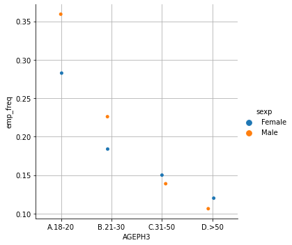

```python
EmpFreq_by_age_sex = my_data.groupby(['AGEPH3','sexp']).agg(count = ('nbrtotc', 'count'),tot_claims = ('nbrtotc', 'sum'), tot_expo = ('duree', 'sum'))

EmpFreq_by_age_sex.reset_index(inplace = True)
EmpFreq_by_age_sex['emp_freq'] = EmpFreq_by_age_sex['tot_claims'] / EmpFreq_by_age_sex['tot_expo']
EmpFreq_by_age_sex.head()


plt.figure(figsize=(50,40))
sb.catplot(x='AGEPH3',y='emp_freq',data=EmpFreq_by_age_sex,hue='sexp')
plt.grid()
```

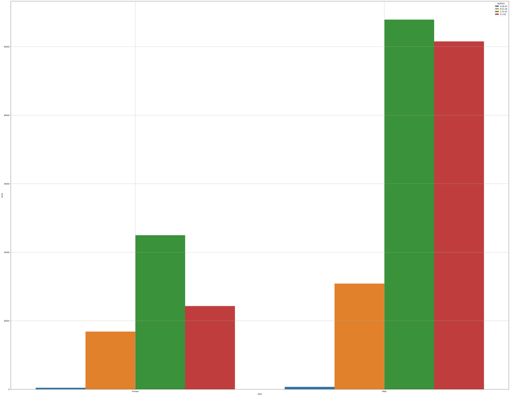

```python
plt.figure(figsize=(50,40))
sb.barplot(x='sexp',y='count',data=EmpFreq_by_age_sex,hue='AGEPH3')
plt.grid()
```

=> Interaction observée entre les deux variables:

- les hommes de moins 30 ans ont une fréquence plus élevée
- les femmes de plus de 30 ans sont plus risquées

### Age du véhicule

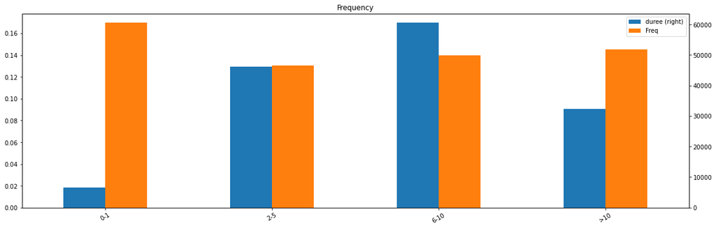

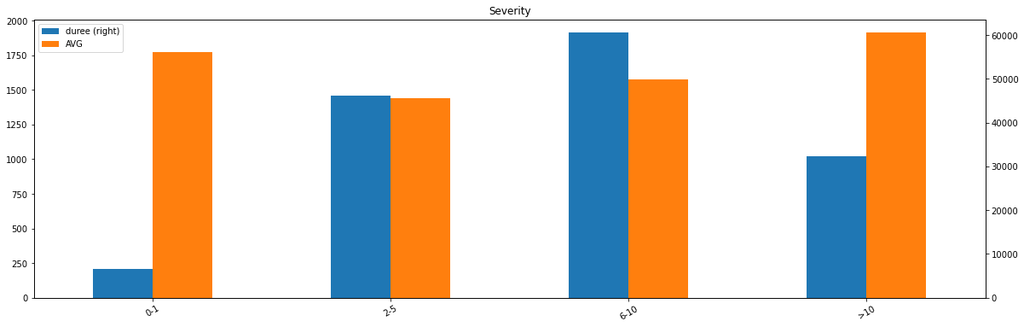

|  | agecar | nbrtotc | duree | chargtot | Freq | AVG |
| --- | --- | --- | --- | --- | --- | --- |
| 0 | 0-1 | 1115 | 6570.191781 | 1.975692e+06 | 0.169706 | 1771.921349 |
| 1 | 2-5 | 6029 | 46189.060274 | 8.671438e+06 | 0.130529 | 1438.287975 |
| 2 | 6-10 | 8453 | 60555.106849 | 1.328777e+07 | 0.139592 | 1571.958622 |
| 3 | >10 | 4693 | 32305.369863 | 8.976585e+06 | 0.145270 | 1912.760498 |

```python
description_analysis2("agecar",my_data)
```

**Constatations:**

- On observe une fréquence & sévérité importante pour les véhicules les plus récents (< 1 an) (! exposition faible)
- le coût moyen des véhicules de plus de 10 ans est également plus élevé

### Sexe du preneur

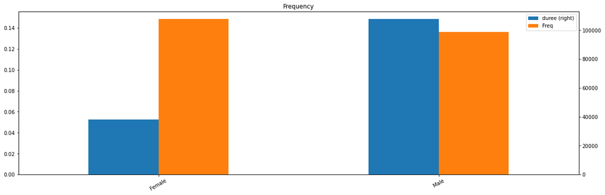

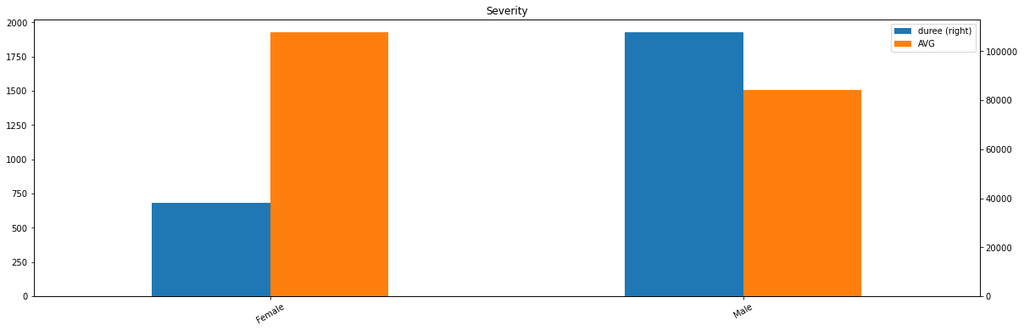

|  | sexp | nbrtotc | duree | chargtot | Freq | AVG |
| --- | --- | --- | --- | --- | --- | --- |
| 0 | Female | 5640 | 38001.589041 | 1.085424e+07 | 0.148415 | 1924.510185 |
| 1 | Male | 14650 | 107618.139726 | 2.205724e+07 | 0.136129 | 1505.613947 |

```python
description_analysis2("sexp",my_data)
```

**Constatations:**

- fréquence sinistres & coût moyen légèrement plus important pour les femmes

### Type de carburant

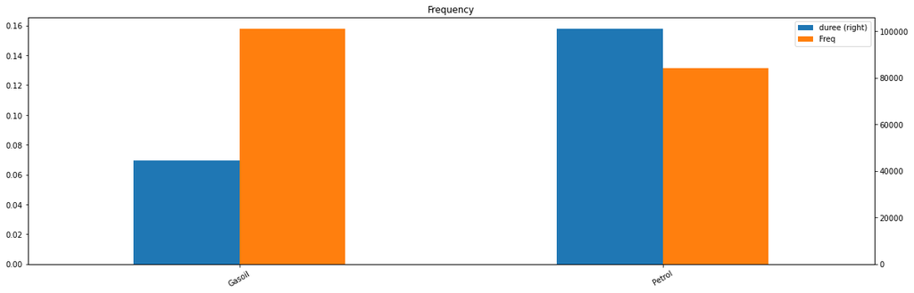

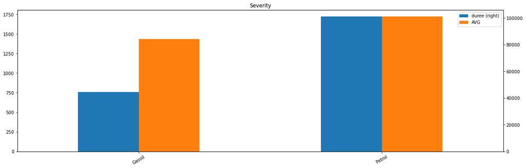

|  | fuelc | nbrtotc | duree | chargtot | Freq | AVG |
| --- | --- | --- | --- | --- | --- | --- |
| 0 | Gasoil | 7040 | 44613.397260 | 1.008824e+07 | 0.15780 | 1432.988704 |
| 1 | Petrol | 13250 | 101006.331507 | 2.282324e+07 | 0.13118 | 1722.508776 |

```python
description_analysis2("fuelc",my_data)
```

**Constatations:**

- les véhicules Diesel ont une fréquence plus importante
- alors que le coût moyen est plus important pour les véhicules Essence

### Fractionnement de la prime

```python
my_data["split1"] = np.where(my_data['split']=="Once" , "A.Once", \
                             np.where(my_data['split']=="Twice" , "B.Twice", \
                            np.where(my_data['split']=="Thrice" , "C.Trice", \
                             "D.Monthly")))
```

```python
my_data.split1.value_counts()
```

```
A.Once       81479
B.Twice      45961
D.Monthly    23599
C.Trice      12618
Name: split1, dtype: int64
```

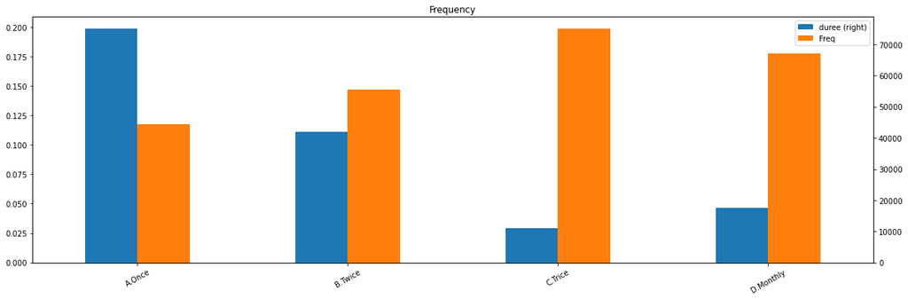

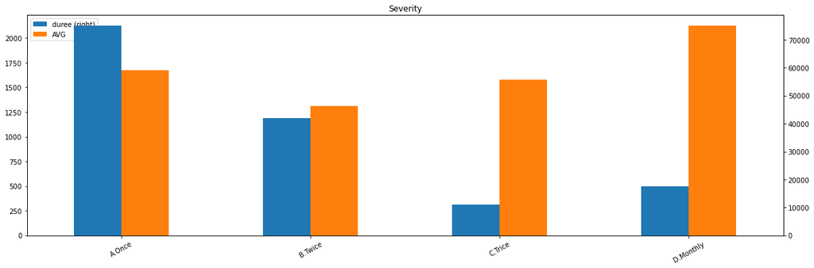

|  | split1 | nbrtotc | duree | chargtot | Freq | AVG |
| --- | --- | --- | --- | --- | --- | --- |
| 0 | A.Once | 8818 | 75070.876712 | 1.474234e+07 | 0.117462 | 1671.846582 |
| 1 | B.Twice | 6165 | 41997.008219 | 8.098743e+06 | 0.146796 | 1313.664761 |
| 2 | C.Trice | 2207 | 11105.052055 | 3.479737e+06 | 0.198738 | 1576.682083 |
| 3 | D.Monthly | 3100 | 17446.791781 | 6.590658e+06 | 0.177683 | 2126.018704 |

```python
description_analysis2("split1",my_data)
```

**Constatations:**

- la fréquence augmente avec le nombre de fractionnement,sauf pour le fractionnement Mensuel
- le coût moyen augmente avec le fractionnement, sauf pour le fractionnement annuel

### Usage du véhicule

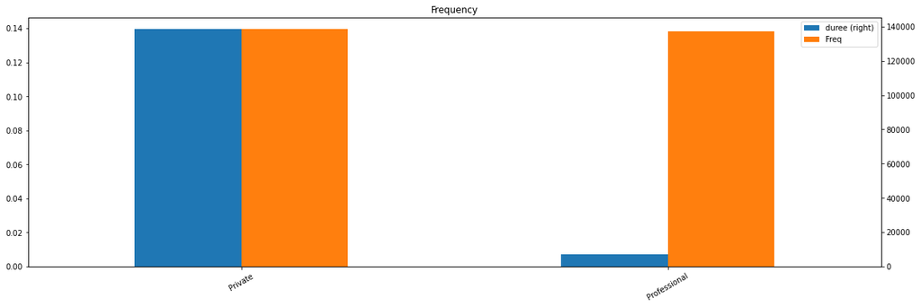

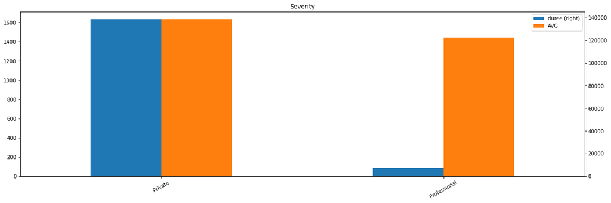

|  | usec | nbrtotc | duree | chargtot | Freq | AVG |
| --- | --- | --- | --- | --- | --- | --- |
| 0 | Private | 19290 | 138394.630137 | 3.146557e+07 | 0.139384 | 1631.185678 |
| 1 | Professional | 1000 | 7225.098630 | 1.445910e+06 | 0.138406 | 1445.910030 |

```python
description_analysis2("usec",my_data)
```

**Constatations:**

- fréquence: pas de différence observée selon l'usage du véhicule
- coût moyen : le coût moyen est légèrement plus important pour l'usage privé (! exposition faible pour Professional)

### Flottes

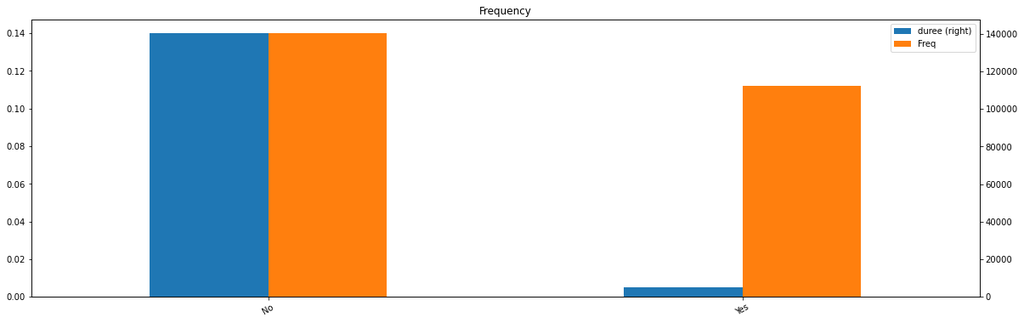

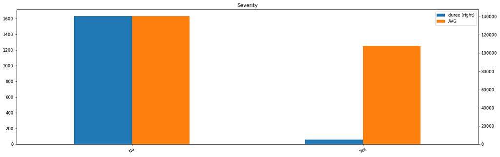

|  | fleetc | nbrtotc | duree | chargtot | Freq | AVG |
| --- | --- | --- | --- | --- | --- | --- |
| 0 | No | 19728 | 140611.580822 | 3.220790e+07 | 0.140301 | 1632.598085 |
| 1 | Yes | 562 | 5008.147945 | 7.035867e+05 | 0.112217 | 1251.933713 |

```python
description_analysis2("fleetc",my_data)
```

**Constatations:**  
La fréquence sinistres & le coût moyen ne sont pas plus important pour les flottes  
! l'exposition est très faible => difficile de tirer des conclusions

### Sport

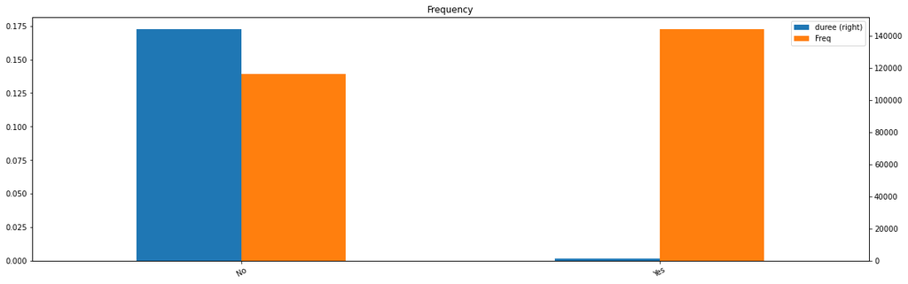

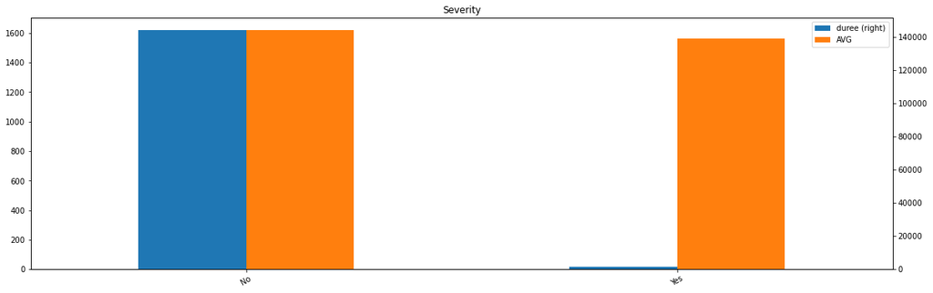

|  | sportc | nbrtotc | duree | chargtot | Freq | AVG |
| --- | --- | --- | --- | --- | --- | --- |
| 0 | No | 20061 | 144294.778082 | 3.255415e+07 | 0.139028 | 1622.758300 |
| 1 | Yes | 229 | 1324.950685 | 3.573275e+05 | 0.172837 | 1560.382138 |

```python
description_analysis2("sportc",my_data)
```

**Constatations:**

- Les vehicules sportifs ont une fréquence plus importante
- Pas de différence au niveau du coût moyen

### Couvertures

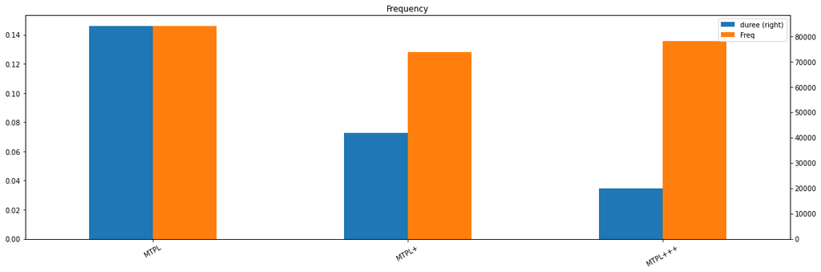

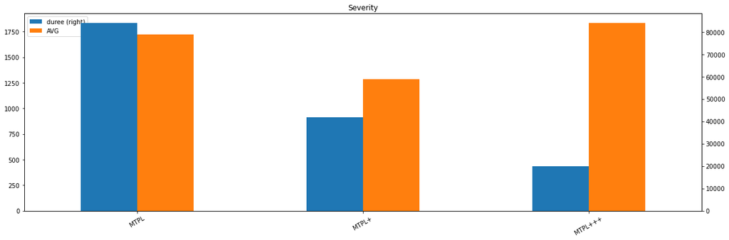

|  | coverp | nbrtotc | duree | chargtot | Freq | AVG |
| --- | --- | --- | --- | --- | --- | --- |
| 0 | MTPL | 12261 | 84012.597260 | 2.111275e+07 | 0.145942 | 1721.943903 |
| 1 | MTPL+ | 5342 | 41759.449315 | 6.867398e+06 | 0.127923 | 1285.548070 |
| 2 | MTPL+++ | 2687 | 19847.682192 | 4.931330e+06 | 0.135381 | 1835.254847 |

```python
description_analysis2("coverp",my_data)
```

**Constatations:**

- Fréquence : pas de différence claire
- Coût moyen : plus important pour la couverture MTPL+++ (la plus large)

### Puissance du véhicule

```python
my_data.powerc.value_counts()
```

```
<66       119809
66-110     42188
>110        1660
Name: powerc, dtype: int64
```

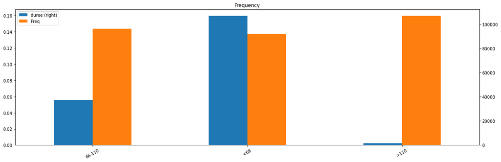

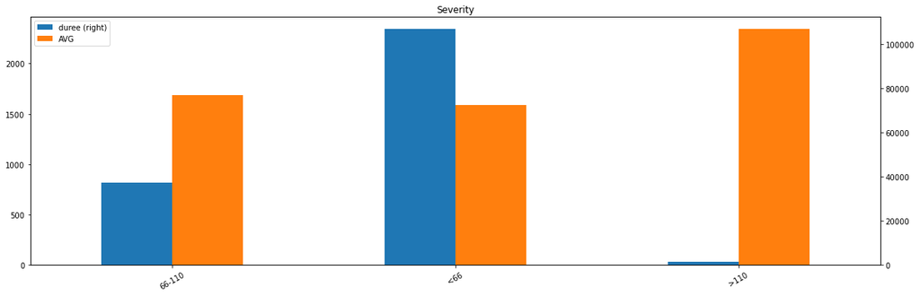

|  | powerc | nbrtotc | duree | chargtot | Freq | AVG |
| --- | --- | --- | --- | --- | --- | --- |
| 0 | 66-110 | 5361 | 37340.164384 | 9.050775e+06 | 0.143572 | 1688.262384 |
| 1 | <66 | 14700 | 106846.843836 | 2.332403e+07 | 0.137580 | 1586.668661 |
| 2 | >110 | 229 | 1432.720548 | 5.366778e+05 | 0.159836 | 2343.571202 |

```python
description_analysis2("powerc",my_data)
```

```python
my_data["powerc1"] = np.where(my_data['powerc']=="<66" , "A.<66", \
                            "B.>66")
```

```python
my_data.powerc1.value_counts()
```

```
A.<66    119809
B.>66     43848
Name: powerc1, dtype: int64
```

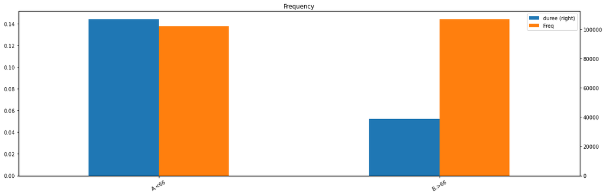

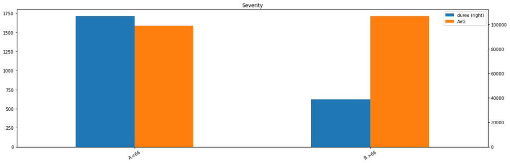

|  | powerc1 | nbrtotc | duree | chargtot | Freq | AVG |
| --- | --- | --- | --- | --- | --- | --- |
| 0 | A.<66 | 14700 | 106846.843836 | 2.332403e+07 | 0.137580 | 1586.668661 |
| 1 | B.>66 | 5590 | 38772.884932 | 9.587452e+06 | 0.144173 | 1715.107772 |

```python
description_analysis2("powerc1",my_data)
```

**Constatations:**

- La fréquence et coût moyen augmentent avec la puissance du véhicule